# Tony_week1

Tony Daza

2023-04-28

# Week 1 Reflections

**Week 1 Reflection**

Week 1 was a little hectic as I was asked to prepared a last minute presentation for a conference so in truth, I did not have a chance to dive into the data as much as I would have liked.

**Questions about the data**

I am not entirely sure if I should be using the confidential-dataset, the public-dataset, or data from the data cleaning Rmd.

I am struggling with interpreting the race data in the internal data set for school leaders.

**Specific findings**

One finding is that I need to figure out if schools really have zero percent BIPOC students or if it is a reporting issue. There seem to be a lot of schools that report zero percent for the different racial groups.

# Student Demographic Data

## Student Race/Ethnicity

### Frequency Graphs

```r
summary(dat_con[157:166])
```

```
##  self_reported_math self_reported_race_aian self_reported_race_asian
##  Min.   : 0.00      Min.   :  0.000         Min.   : 0.000
##  1st Qu.:24.00      1st Qu.:  0.000         1st Qu.: 0.000
##  Median :42.65      Median :  0.000         Median : 1.000
##  Mean   :42.10      Mean   :  2.449         Mean   : 4.062
##  3rd Qu.:58.00      3rd Qu.:  1.000         3rd Qu.: 4.000
##  Max.   :94.00      Max.   :100.000         Max.   :55.000
##  NA's   :113        NA's   :8               NA's   :8
##  self_reported_race_black self_reported_race_hispanic
##  Min.   :  0.00           Min.   :  0.00
##  1st Qu.:  2.00           1st Qu.:  5.00
##  Median : 10.00           Median : 14.00
##  Mean   : 24.46           Mean   : 27.54
##  3rd Qu.: 38.00           3rd Qu.: 46.50
##  Max.   :100.00           Max.   :100.00
##  NA's   :8                NA's   :8
##  self_reported_race_multiple self_reported_race_nhpi
##  Min.   :  0.000             Min.   : 0.000
##  1st Qu.:  1.000             1st Qu.: 0.000
##  Median :  3.000             Median : 0.000
##  Mean   :  5.621             Mean   : 0.716
##  3rd Qu.:  7.000             3rd Qu.: 0.000
##  Max.   :100.000             Max.   :78.000
##  NA's   :8                   NA's   :8
##  self_reported_race_none_collected self_reported_race_white self_reported_swd
##  Min.   :0.00000                   Min.   :  0.00           Min.   :  0.00
##  1st Qu.:0.00000                   1st Qu.:  4.50           1st Qu.: 10.00
##  Median :0.00000                   Median : 29.00           Median : 15.00
##  Mean   :0.03187                   Mean   : 34.77           Mean   : 18.13
##  3rd Qu.:0.00000                   3rd Qu.: 62.00           3rd Qu.: 22.25
##  Max.   :1.00000                   Max.   :100.00           Max.   :100.00
##                                    NA's   :8                NA's   :7
```

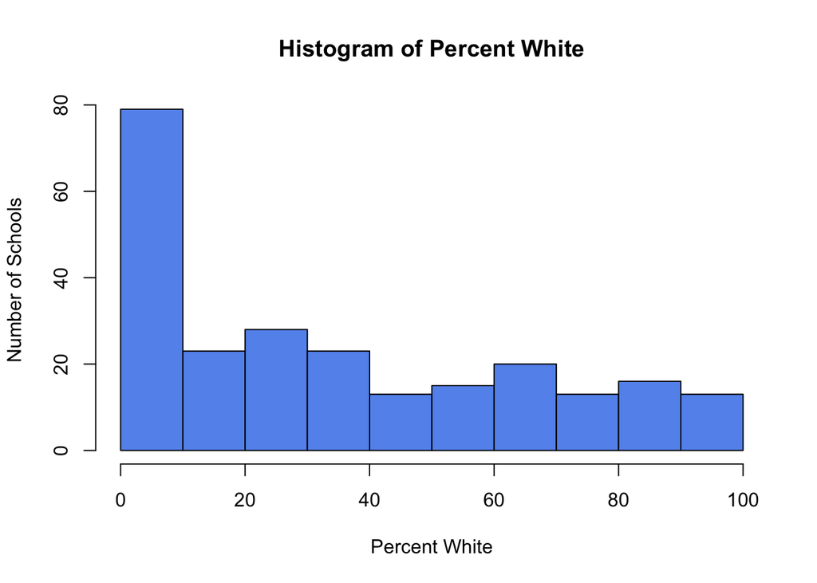

```r
hist(dat_con$self_reported_race_white, col = "cornflowerblue",
     main = paste("Histogram of Percent White"),
     xlab = "Percent White",
     ylab = "Number of Schools",
     axes = TRUE, plot = TRUE, labels = FALSE)
```

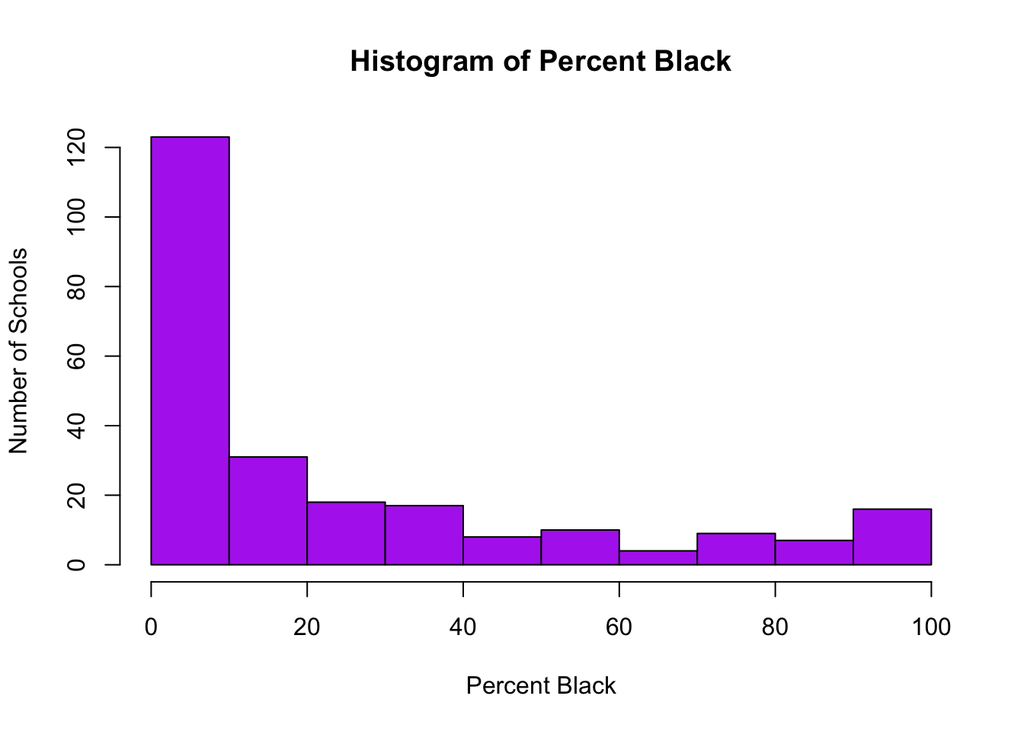

```r
hist(dat_con$self_reported_race_black , col = "darkorchid2",
     main = paste("Histogram of Percent Black"),
     xlab = "Percent Black",
     ylab = "Number of Schools",
     axes = TRUE, plot = TRUE, labels = FALSE)
```

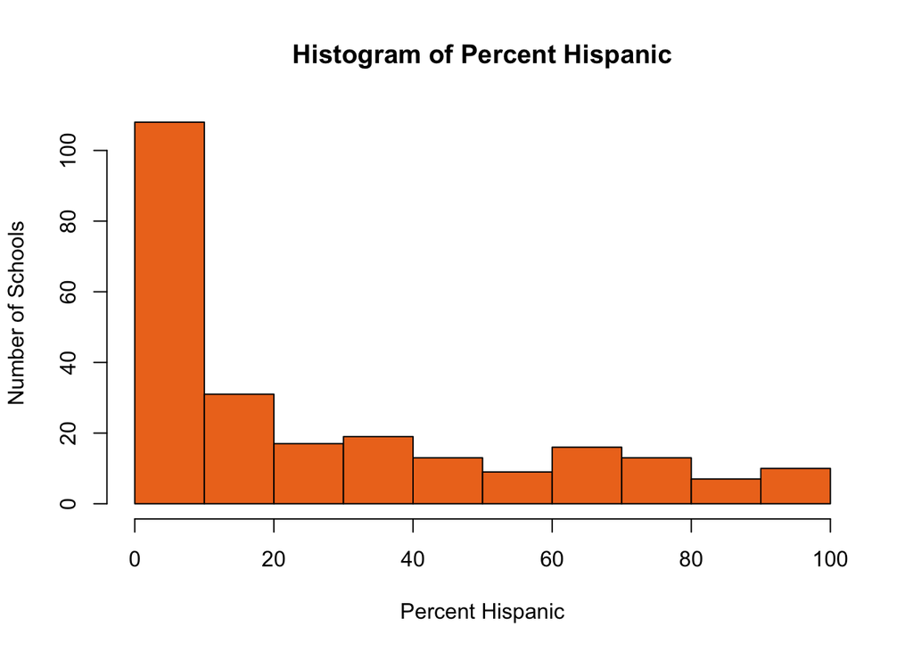

```r
hist(dat_con$self_reported_race_hispanic , col = "chocolate2",
     main = paste("Histogram of Percent Hispanic"),
     xlab = "Percent Hispanic",
     ylab = "Number of Schools",
     axes = TRUE, plot = TRUE, labels = FALSE)
```

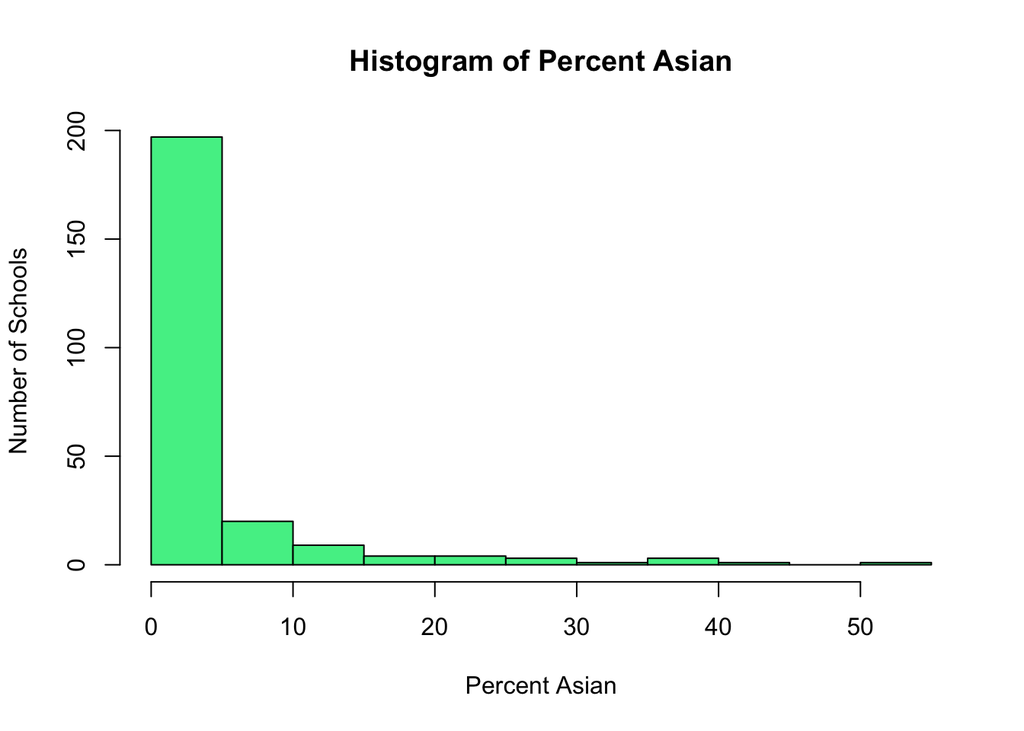

```r
hist(dat_con$self_reported_race_asian , col = "seagreen2",
     main = paste("Histogram of Percent Asian"),
     xlab = "Percent Asian",
     ylab = "Number of Schools",
     axes = TRUE, plot = TRUE, labels = FALSE)
```

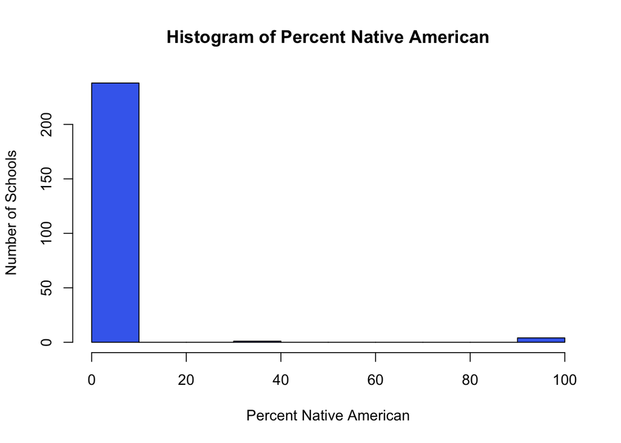

```r
hist(dat_con$self_reported_race_aian , col = "royalblue2",
     main = paste("Histogram of Percent Native American"),
     xlab = "Percent Native American",
     ylab = "Number of Schools",
     axes = TRUE, plot = TRUE, labels = FALSE)
```

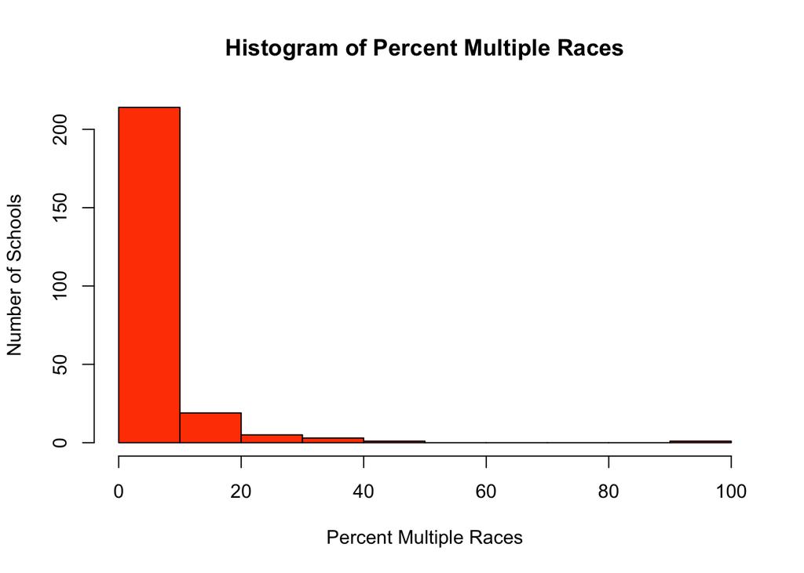

```r
hist(dat_con$self_reported_race_multiple , col = "orangered1",
     main = paste("Histogram of Percent Multiple Races"),
     xlab = "Percent Multiple Races",
     ylab = "Number of Schools",
     axes = TRUE, plot = TRUE, labels = FALSE)
```

**It seems like the schools reporting zero percent of each ethnicity is larger than expected for all groups**

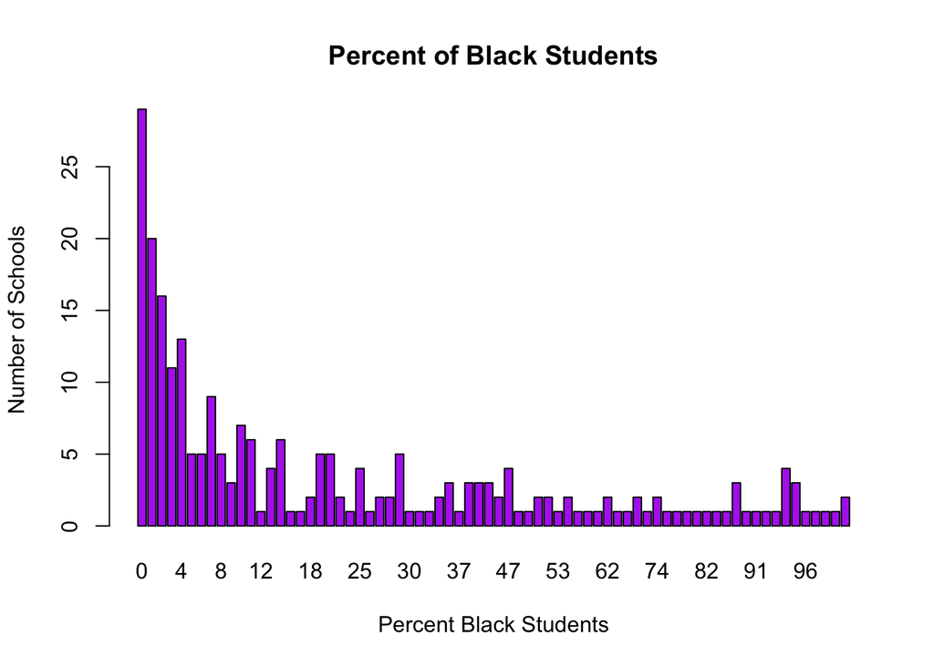

```r
barplot(table(dat_con$self_reported_race_black), col = "darkorchid2",
        main = "Percent of Black Students",
        xlab = "Percent Black Students",
        ylab = "Number of Schools")
```

Same information, different format. I think the barplot potentially shows the range better.

**Last year they used violin plots**

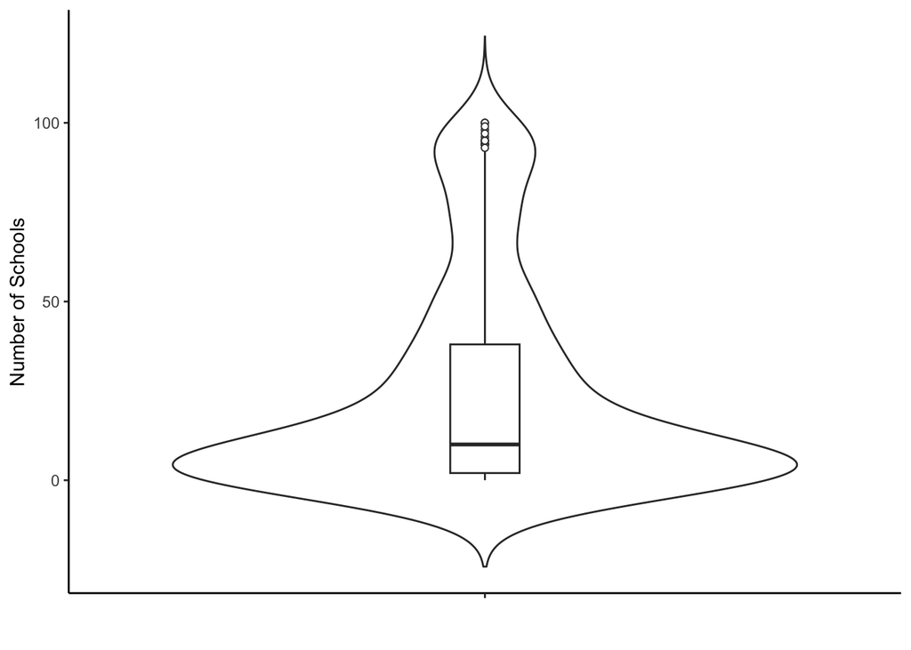

```r
ggplot(data = dat_con, aes(x = "", y = self_reported_race_black, fill = self_reported_race_black)) +
  geom_violin(trim = FALSE) +
  geom_boxplot(width = 0.1, fill = "white", outlier.shape = 21) +
  scale_fill_brewer(palette = "Set1") +
  labs(x = "", y = "Number of Schools") +
  theme_classic() +
  theme(legend.position = "none")
```

I am not super familiar with violin plots so I need to revise this. I want all the schools to be in one plot though.

### Violin Plots

**This should show all of the violin plots together**

It might make sense to collapse non-white into one group for a visualization as well.

I don’t like how the scales are different but it is a work in progress.

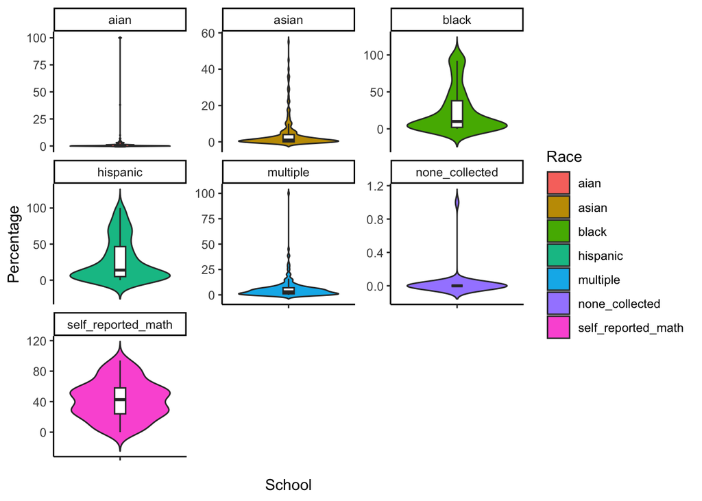

```r
# Selecting just the student race data and school name
dat_con_short <- dat_con[c(3,157:162,164)]

# Creating a long version of the data
dat_con_long <- melt(dat_con_short, id.vars = "school_name",
                    variable.name = "Race",
                    value.name = "Percentage")

# Removing the prefix in front of the race data
dat_con_long$Race <- gsub("^self_reported_race_", "", dat_con_long$Race)


# Violin plots, but it is by school so it needs to be merged to clean it.
 vio_race <- ggplot(data = dat_con_long, aes(x = " ", y = Percentage, fill = Race)) +
  geom_violin(trim = FALSE) +
  geom_boxplot(width = 0.1, fill = "white", outlier.shape = NA) +
  labs(x = "School", y = "Percentage", fill = "Race") +
  theme_classic()

plot_grid(vio_race + facet_wrap(~Race, scales = "free_y"), ncol = 1)
```

# School Leader Demographics

## School Leader Race Data

**This is a work in progress** I am struggling with interpreting the race data in the internal data set.